# Heart Disease Prediction

## 6. Model Building: Part 2

To estimate the total effect of pfoa4 on hadcvd, we need to include pfoa4, education(DMDEDUC), ethnicity(RIDRETH1), age(RIDAGEEX), gender(RIAGENDR) and smoking.

Blood pressure(BPXSAR, BPXDAR), cholesterol(LBXTC) and diabetes(LBXGH) should be excluded because they are on indirect causal pathways from pfoa4 to hadcvd.

All confounding pathways should be closed, so we need to include education(DMDEDUC), ethnicity(RIDRETH1) and age(RIDAGEEX) which are confounders for pfoa4.

We also need to include age(RIDAGEEX), smoking and gender(RIAGENDR) as they have direct effects on hadcvd.

### Fitting a GLM model using these variables

```r
pfoa.glm2 <- glm(hadcvd ~ pfoa4 + DMDEDUC + RIDRETH1 + RIDAGEEX + smoking + RIAGENDR, family="binomial", data=pfoa.new)
summary(pfoa.glm2)
```

```
##
## Call:
## glm(formula = hadcvd ~ pfoa4 + DMDEDUC + RIDRETH1 + RIDAGEEX +
##     smoking + RIAGENDR, family = "binomial", data = pfoa.new)
##
## Coefficients:
##                             Estimate Std. Error z value Pr(>|z|)
## (Intercept)                -5.292660   0.519633 -10.185  < 2e-16
## pfoa4Q2                     0.282694   0.214696   1.317   0.1879
## pfoa4Q3                     0.492916   0.215775   2.284   0.0223
## pfoa4Q4                     0.412096   0.240440   1.714   0.0865
## DMDEDUCHigh school         -0.274827   0.212296  -1.295   0.1955
## DMDEDUC> High school       -0.644113   0.205224  -3.139   0.0017
## RIDRETH1Other Hispanic     -0.211536   0.509763  -0.415   0.6782
## RIDRETH1non-Hispanic White  0.512212   0.229981   2.227   0.0259
## RIDRETH1non-Hispanic Black  0.521207   0.263646   1.977   0.0481
## RIDRETH1other               1.433545   0.454285   3.156   0.0016
## RIDAGEEX                    0.053664   0.007378   7.274 3.49e-13
## smokingFormer               0.006849   0.232724   0.029   0.9765
## smokingNever               -0.417742   0.236499  -1.766   0.0773
## RIAGENDRFemale             -0.349141   0.166541  -2.096   0.0360
##
## (Intercept)                ***
## pfoa4Q2
## pfoa4Q3                    *
## pfoa4Q4                    .
## DMDEDUCHigh school
## DMDEDUC> High school       **
## RIDRETH1Other Hispanic
## RIDRETH1non-Hispanic White *
## RIDRETH1non-Hispanic Black *
## RIDRETH1other              **
## RIDAGEEX                   ***
## smokingFormer
## smokingNever               .
## RIAGENDRFemale             *
## ---
## Signif. codes:  0 '***' 0.001 '**' 0.01 '*' 0.05 '.' 0.1 ' ' 1
##
## (Dispersion parameter for binomial family taken to be 1)
##
##     Null deviance: 1190.7  on 1455  degrees of freedom
## Residual deviance: 1073.2  on 1442  degrees of freedom
## AIC: 1101.2
##
## Number of Fisher Scoring iterations: 5
```

RIDAGEEX is very statistically significant so we should not drop it. There are some evidence that suggest keeping DMDEDUC, RIDRETH1 and RIAGENDR in the model.

```r
pfoa.gam2 <- gam(hadcvd ~ pfoa4 + DMDEDUC + RIDRETH1 + s(RIDAGEEX) + smoking + RIAGENDR, family="binomial", data=pfoa.new)
print(summary(pfoa.gam2)$p.table)
```

```
##                                Estimate Std. Error     z value
## (Intercept)                -2.090075816  0.2738827 -7.63128165
## pfoa4Q2                     0.300628729  0.2147377  1.39998137
## pfoa4Q3                     0.507015733  0.2158655  2.34875708
## pfoa4Q4                     0.419542885  0.2407692  1.74251068
## DMDEDUCHigh school         -0.266754487  0.2123312 -1.25631328
## DMDEDUC> High school       -0.640055701  0.2052720 -3.11808541
## RIDRETH1Other Hispanic     -0.197018703  0.5104650 -0.38595930
## RIDRETH1non-Hispanic White  0.562616368  0.2308524  2.43712598
## RIDRETH1non-Hispanic Black  0.541482570  0.2645928  2.04647537
## RIDRETH1other               1.468838311  0.4567516  3.21583646
## smokingFormer              -0.009143161  0.2331956 -0.03920812
## smokingNever               -0.407108267  0.2373401 -1.71529527
## RIAGENDRFemale             -0.356210362  0.1666264 -2.13777917
##                                Pr(>|z|)
## (Intercept)                2.324313e-14
## pfoa4Q2                    1.615189e-01
## pfoa4Q3                    1.883619e-02
## pfoa4Q4                    8.141912e-02
## DMDEDUCHigh school         2.090024e-01
## DMDEDUC> High school       1.820300e-03
## RIDRETH1Other Hispanic     6.995268e-01
## RIDRETH1non-Hispanic White 1.480452e-02
## RIDRETH1non-Hispanic Black 4.070962e-02
## RIDRETH1other              1.300649e-03
## smokingFormer              9.687245e-01
## smokingNever               8.629110e-02
## RIAGENDRFemale             3.253467e-02
```

```r
print(summary(pfoa.gam2)$s.table)
```

```
##                  edf   Ref.df   Chi.sq p-value
## s(RIDAGEEX) 2.432501 3.042903 52.36661       0
```

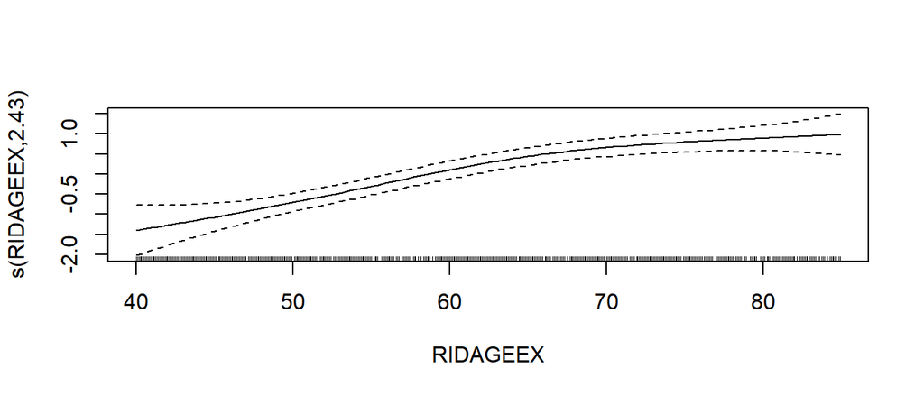

```r
plot(pfoa.gam2)
```

RIDAGEEX has a edf value greater than 2 and there is some indication of non-linearity in the plot. I will consider adding a quadratic term for RIDAGEEX.